# Untitled

### **原始数据分布**

收集了180个扣件的重量数据，一共6袋，每袋30个扣件

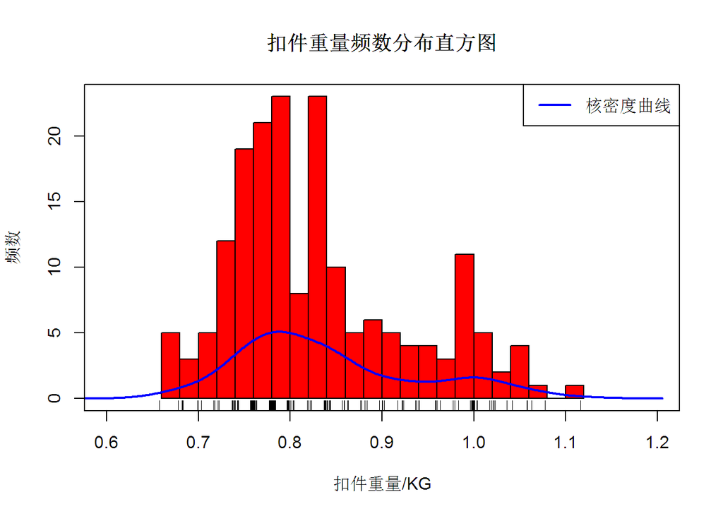

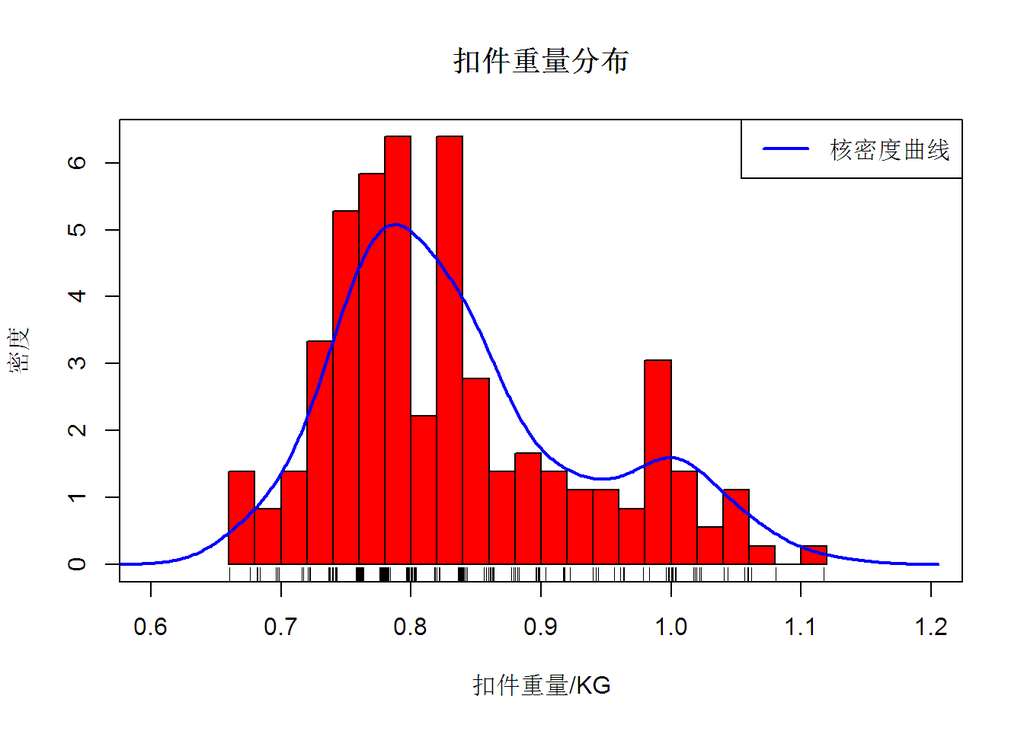

```
## Package 'sm', version 2.2-5.6: type help(sm) for summary information
```

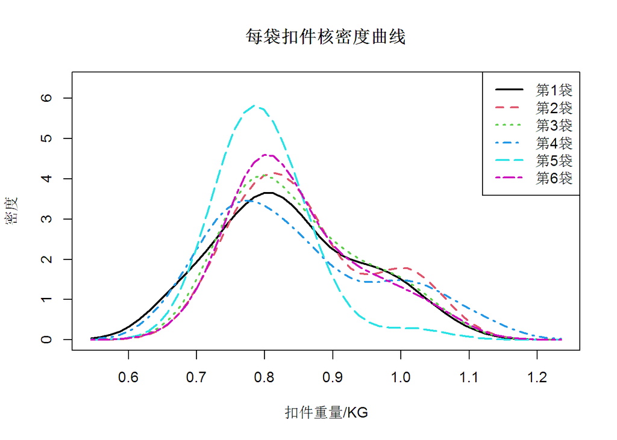

### **可以看出单个扣件重量集中在0.8kg左右**

#### 以收集到的180个扣件重量为样本

每次随机从中取出30个扣件，并计算30个扣件总重量(相当于30个一袋的重量)，一共进行1000次，相当于模拟了1000个扣件袋子。

每次随机从中取出29个扣件，并计算29个扣件总重量(相当于29个一袋的重量)，一共进行1000次，相当于模拟了1000个扣件袋子。

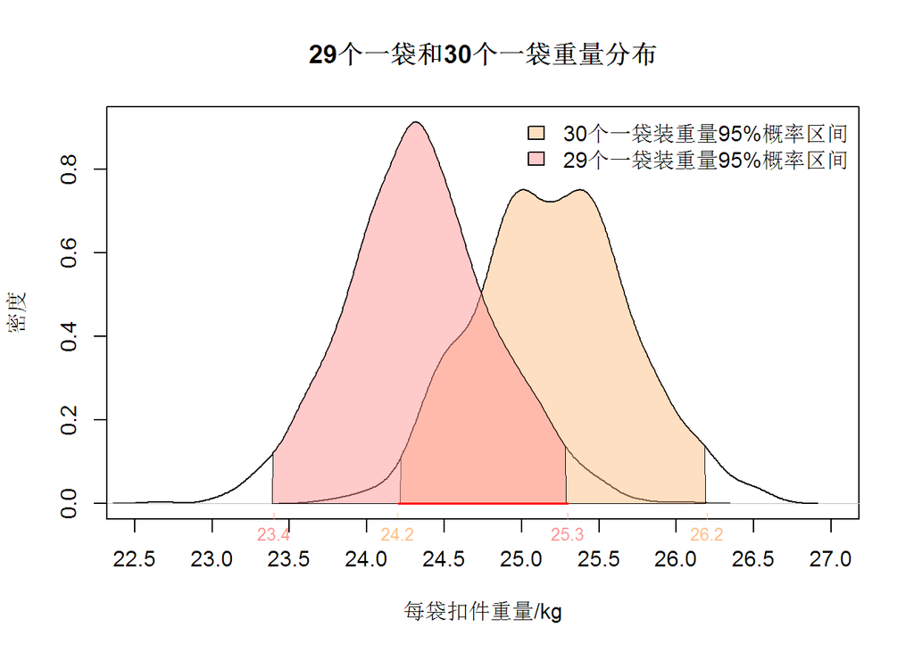

由上图可以看出：

30个扣件装一袋的重量其95%的概率区间是在24.2-26.2kg，表示随机从样本中抽取30个扣件作为一袋，

抽取100次，其中95次袋子的重量在24.2-26.2kg区间内；

29个扣件装一袋的重量其95%的概率区间是在23.4-25.3kg，表示随机从样本中抽取29个扣件作为一袋，

抽取100次，其中95次袋子的重量在23.4-25.3kg区间内；

由于30袋和29袋装重量95%概率区间在24.2-25.3kg部分重合，对于那些重量在该区间的扣件我们无法判断其实来自29袋还是30袋。

因此30个一袋无法根据重量验收。

### 最佳装袋数

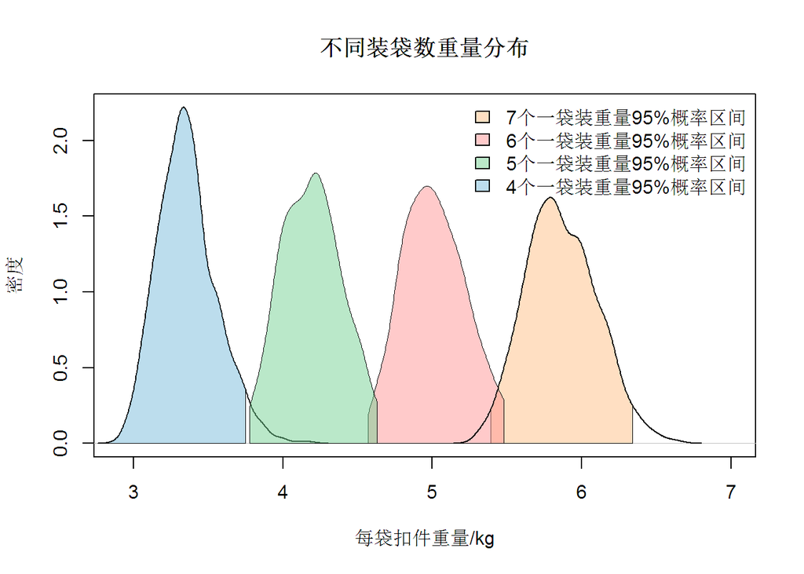